# A Tutorial of Sample-Pseudotime Aanalysis on COVID scRNA-seq Data

Runzhe Li

Johns Hopkins University

rli51@jhmi.edu

2022-01-15

#### Abstract

# 1 Load packages

```r
library(tidyverse)
library(TSCAN)
library(ggpubr)
library(RColorBrewer)
library(mgcv)
library(ComplexHeatmap)
```

# 2 Load data

- `pbpca`: the top 20 PCs of pseudo-bulk gene expression data
- `cell_prop_pca`: the top 3 PCs of cell type proportion data
- `patient_info`: the patient-level metadata
- `sample_info_pb_center`: the patient-level metadata with predefined sample cluster info.

```r
pbpca = readRDS("./data/pbpca.rds")
cell_prop_pca = readRDS("./data/cell_prop_pca.rds")
patient_info = readRDS("./data/patient_info.rds")
sample_info_pb_center = readRDS("./data/sample_info_pb_center.rds")

print(str(pbpca))
```

```
##  num [1:400, 1:20] 39.9 49 -14 -11.4 38.6 ...
##  - attr(*, "dimnames")=List of 2
##   ..$ : chr [1:400] "CoV-1.1-Wilk" "CoV-1.2-Wilk" "CoV-100.1-Su" "CoV-100.2-Su" ...
##   ..$ : chr [1:20] "PC1" "PC2" "PC3" "PC4" ...
## NULL
```

```r
print(str(cell_prop_pca))
```

```
##  num [1:400, 1:3] -0.2087 -0.1513 -0.0968 -0.1888 -0.7362 ...
##  - attr(*, "dimnames")=List of 2
##   ..$ : chr [1:400] "CoV-1.1-Wilk" "CoV-1.2-Wilk" "CoV-100.1-Su" "CoV-100.2-Su" ...
##   ..$ : chr [1:3] "PC1" "PC2" "PC3"
## NULL
```

```r
print(head(patient_info))
```

```
##   Numbers.of.scRNASeq                       Paper.code Subject.type  WOS Orig
## 1                   1 Wilk et al.Nature Medicine, 2020         HD-1 <NA>   H1
## 2                   2 Wilk et al.Nature Medicine, 2020         HD-2 <NA>   H2
## 3                   3 Wilk et al.Nature Medicine, 2020         HD-3 <NA>   H3
## 4                   4 Wilk et al.Nature Medicine, 2020         HD-4 <NA>   H4
## 5                   5 Wilk et al.Nature Medicine, 2020         HD-5 <NA>   H5
## 6                   6 Wilk et al.Nature Medicine, 2020         HD-6 <NA>   H6
##   Age Sex Sample.status Lung.Diseases Cardio Other.comorbidities
## 1  49   F   Fresh PBMCs          <NA>   <NA>                <NA>
## 2  49   M   Fresh PBMCs          <NA>   <NA>                <NA>
## 3  36   F   Fresh PBMCs          <NA>   <NA>                <NA>
## 4  49   M   Fresh PBMCs          <NA>   <NA>                <NA>
## 5  48   M   Fresh PBMCs          <NA>   <NA>                <NA>
## 6  37   M   Fresh PBMCs          <NA>   <NA>                <NA>
##   Known.drug.treatment Clinical.Outcome   Patient Phenotype Study     ARDS
## 1                 <NA>             <NA> HD-1-Wilk        HD  Wilk w/o ARDS
## 2                 <NA>             <NA> HD-2-Wilk        HD  Wilk w/o ARDS
## 3                 <NA>             <NA> HD-3-Wilk        HD  Wilk w/o ARDS
## 4                 <NA>             <NA> HD-4-Wilk        HD  Wilk w/o ARDS
## 5                 <NA>             <NA> HD-5-Wilk        HD  Wilk w/o ARDS
## 6                 <NA>             <NA> HD-6-Wilk        HD  Wilk w/o ARDS
##   sev.level
## 1         1
## 2         1
## 3         1
## 4         1
## 5         1
## 6         1
```

```r
print(head(sample_info_pb_center))
```

```
##           PC1       PC2       PC3        PC4        PC5        PC6        PC7
## 373  39.90365 -5.917930  37.03118 17.3576245 -0.1203611   9.109701  -6.035842
## 382  49.01155 -6.001411 -14.11673  0.4174759 -6.3402157   9.400043  17.001092
## 129 -14.04680 13.586258  12.85556 48.8398298 -2.5258953 -20.681497  -6.092752
## 144 -11.38984 19.179559  19.04763 36.0739996  0.7158730 -16.773240  -4.872705
## 364  38.63057 18.475166  14.89560  8.7502531 -3.3692104  13.769321  -3.638288
## 358  36.20497 18.814038  12.99122 20.7348649  8.9744626  -8.501155 -10.603132
##           PC8        PC9      PC10       PC11      PC12       PC13        PC14
## 373  2.134569 -21.838929 10.722923 -0.2491645  4.305631  -3.537398   5.6475413
## 382 -7.313915  17.398501 -8.376275 -6.7997916  9.564973 -14.640471   3.4965146
## 129 -3.944402   3.239316  1.594898 15.8662506  4.465585  -4.130181  11.4008587
## 144 -6.683060  12.288636  5.003597 22.8926408 -5.391582  -1.088849   0.3058022
## 364 16.008756  11.471540 12.814328 28.8845932 -1.924394   6.675718   7.8318661
## 358 11.483408  25.132073 22.725989 31.4038083  7.763802  -7.215625 -11.4194572
##           PC15      PC16       PC17       PC18       PC19       PC20
```

[output cut: 34 more lines]

# 3 Construct Sample Pseudotime

To construct pseudotime, we provide the function `get_sample_pseudotime`:

- `x`: the data matrix of features $\times$ samples, i.e. each row is a feature of gene expression or cell type proportion, each column is a patient sample.
- `sample_metadata`: patient-level metadata, including several important variables.
- `sample_name` and `phenotype_name`: the variable name in `sample_metadata` that indicates the sample and phenotype. The default setting of `sample_name` is “Patient” and `phenotype_name` is “Phenotype”.
- `method`: users now have two options, either using TSCAN for sample-level pseudotime construction or use CCA for optimal severity axis detection.
- `cluster = NULL, reduce = F, clusternum = 2, startcluster = 1`: parameters for TSCAN.
- `phenotype_num`: the numerical value to indicate the phenotype severity.

```r
get_sample_pseudotime = function(x, sample_metadata = NULL,
                                 sample_name = 'Patient', phenotype_name = 'Phenotype',
                                 method = c('tscan','cca'),
                                 cluster = NULL, reduce = F, clusternum = 2, startcluster = 1,
                                 phenotype_num = NULL){
  method = match.arg(method)

  ## match x and meta
  match_idx = match(colnames(x), sample_metadata[,sample_name])
  sample_metadata = sample_metadata[match_idx, ]

  ## tscan
  if (method == 'tscan'){
    sample_cluster = exprmclust(x,
                                reduce = reduce,
                                cluster = cluster,
                                clusternum = clusternum)
    sample_metadata$cluster = sample_cluster$clusterid

    sample_order = TSCANorder(sample_cluster,
                              startcluster = startcluster,
                              orderonly = F,
                              listbranch = F)

    sample_info = sample_metadata %>%
      inner_join(sample_order, by = setNames("sample_name",sample_name)) %>%
      arrange(Pseudotime)
  }
  if (method == 'cca'){
    if (reduce) {
      pc = prcomp(t(x), scale = T)$x[1:min(20, nrow(x))]
    }
    else {
      pc = t(x)
    }
    res = cancor(pc,phenotype_num)
    proj = (res$xcoef["PC1",1]*(pc[,"PC1"]-res$xcenter["PC1"]))+ (res$xcoef["PC2",1]*(pc[,"PC1"]-res$xcenter["PC2"]))
    pseudotime = order(proj)
    slope = res$xcoef["PC2",1]/res$xcoef["PC1",1]
    print(paste("slope is", slope))

    sample_info = sample_metadata %>%
      mutate(Pseudotime = pseudotime) %>%
      arrange(Pseudotime)
  }

  return(sample_info)
}
```

# 4 Examples

We will walk through several examples…

## 4.1 Example 1: pseudobulk pca + tscan + model-based clustering with 2 clusters

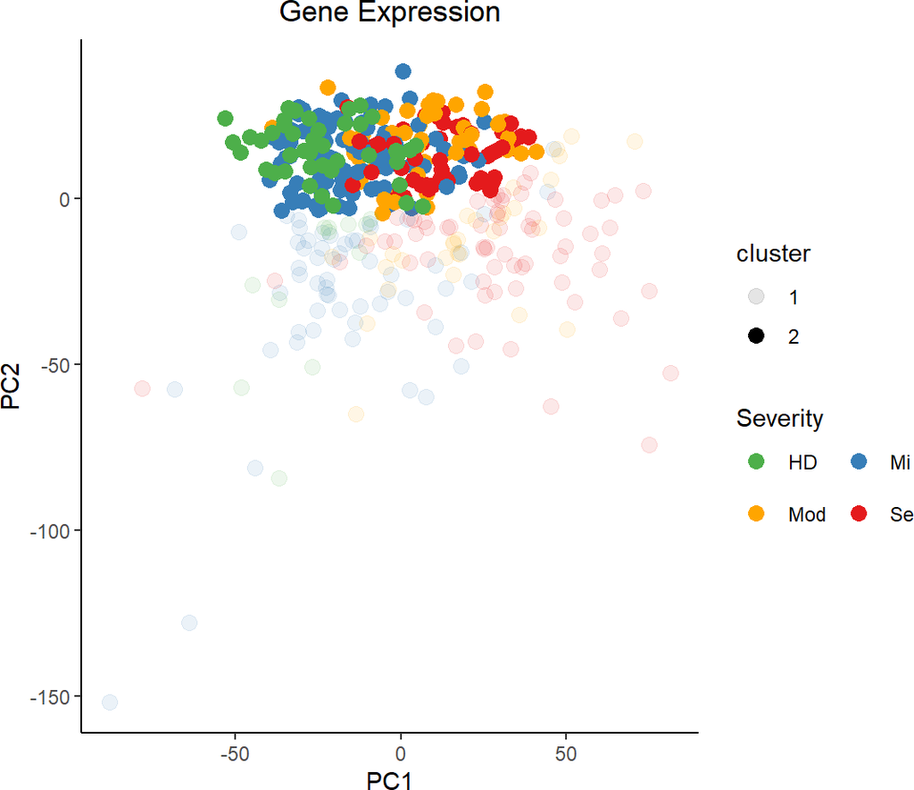

```r
sample_info1 = get_sample_pseudotime(x = t(pbpca[,1:2]), sample_metadata = patient_info,
                                    sample_name = 'Patient', phenotype_name = 'Phenotype',
                                    method = 'tscan',
                                    reduce = F, clusternum = 2, startcluster = 1)
sample_info_pc1 = pbpca %>%
  as.data.frame() %>%
  select(PC1:PC2) %>%
  mutate(Patient = rownames(.)) %>%
  inner_join(sample_info1 %>% select(Patient, Phenotype, cluster, Pseudotime), by = 'Patient')

create_pseudotime_plot(sample_info_pc1, "Gene Expression", cluster = T)
```

## 4.2 Example 2: pseudobulk pca + tscan + predefined 2 clusters connecting HD center and COVID center

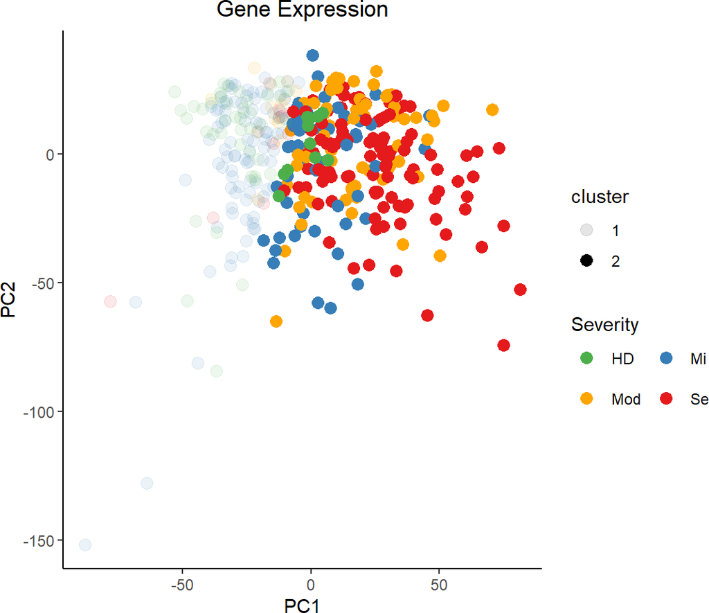

```r
precluster = sample_info_pb_center$cluster; names(precluster) = sample_info_pb_center$Patient
sample_info2 = get_sample_pseudotime(x = t(pbpca[,1:2]), sample_metadata = patient_info,
                                    sample_name = 'Patient', phenotype_name = 'Phenotype',
                                    method = 'tscan', cluster = precluster,
                                    reduce = F, startcluster = 1)
sample_info_pc2 = pbpca %>%
  as.data.frame() %>%
  select(PC1:PC2) %>%
  mutate(Patient = rownames(.)) %>%
  inner_join(sample_info2 %>% select(Patient, Phenotype, cluster, Pseudotime), by = 'Patient')

create_pseudotime_plot(sample_info_pc2, "Gene Expression", cluster = T)
```

## 4.3 Example 3: cell proportion pca + tscan + model-based clustering with 2 clusters

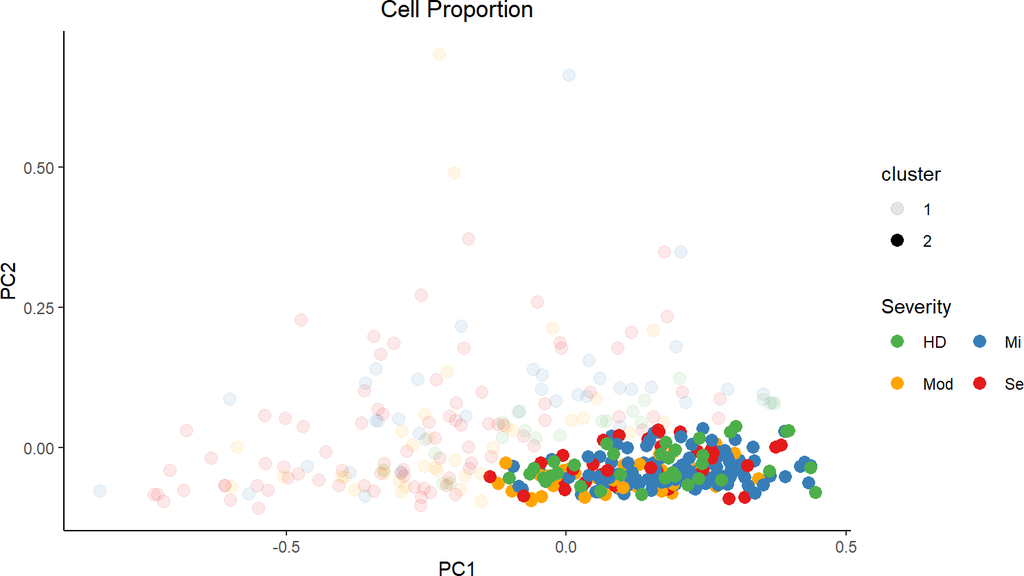

```r
sample_info3 = get_sample_pseudotime(x = t(cell_prop_pca[,1:2]), sample_metadata = patient_info,
                                    sample_name = 'Patient', phenotype_name = 'Phenotype',
                                    method = 'tscan',
                                    reduce = F, clusternum = 2, startcluster = 1)
sample_info_pc3 = cell_prop_pca %>%
  as.data.frame() %>%
  select(PC1:PC2) %>%
  mutate(Patient = rownames(.)) %>%
  inner_join(sample_info3 %>% select(Patient, Phenotype, cluster, Pseudotime), by = 'Patient')

create_pseudotime_plot(sample_info_pc3, "Cell Proportion", cluster = T)
```

## 4.4 Example 4: pseudobulk pca + cca

```r
sev.level = patient_info[match(rownames(pbpca),patient_info$Patient),]$sev.level
sample_info4 = get_sample_pseudotime(x = t(pbpca[,1:2]), sample_metadata = patient_info,
                                     sample_name = 'Patient', phenotype_name = 'Phenotype',
                                     method = 'cca', phenotype_num = sev.level)
```

```
## [1] "slope is -0.151426783245536"
```

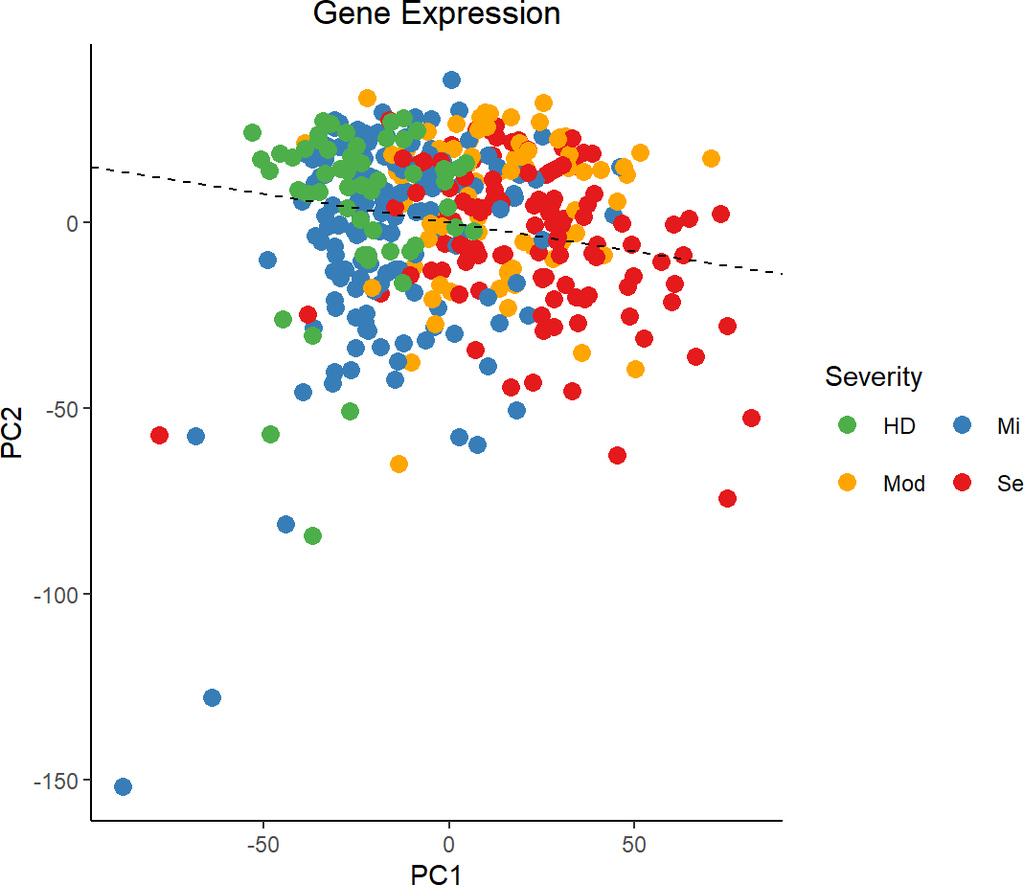

```r
sample_info_pc4 = pbpca %>%
  as.data.frame() %>%
  select(PC1:PC2) %>%
  mutate(Patient = rownames(.)) %>%
  inner_join(sample_info4 %>% select(Patient, Phenotype, Pseudotime), by = 'Patient')

create_pseudotime_plot(sample_info_pc4, "Gene Expression", cluster = F, opt_axis = T)
```

# 5 Explore How Molecular Features Change Along Pseudotime

## 5.1 Cell type proportion

We first load cell type proportion/count data and sample pseudotime results.

```r
cell_type_prop = readRDS("./data/cell_type_prop.rds")
celltype_info = readRDS("./data/celltype_info.rds")
sample_info_opt = readRDS("./data/sample_info_pb_opt.rds")
```

Then we provide the following function `get_cell_prop_traj` to visualize the cell proportion change along pseudotime.

- `cell_type_prop`: the cell type proportion data, each row is a cell cluster and each column is a sample.
- `cluster_list` and `celltype_list`: the cluster list and corresponding celltype list to visualize.
- `sample_metadata`: patient-level metadata, including several important variables.
- `sample_name` and `pseudotime_name`: the variable name in `sample_metadata` that indicates the sample and pseudotime. The default setting of `sample_name` is “Patient” and `phenotype_name` is “Pseudotime”.

```r
get_cell_prop_traj = function(cell_type_prop, cluster_list = NULL, celltype_list = NULL,
                              sample_metadata = NULL,
                              sample_name = 'Patient', pseudotime_name = 'Pseudotime'){
  celltype_label = paste0('c', cluster_list, '\n', celltype_list)
  patient_order = sample_metadata[, sample_name]
  cp = cell_type_prop[cluster_list, match(patient_order,colnames(cell_type_prop)),drop = F]

  cp_df = cp %>%
    as.data.frame() %>%
    mutate(celltype = celltype_label) %>%
    gather(Patient, value, -celltype) %>%
    inner_join(sample_metadata %>% select({{sample_name}}, {{pseudotime_name}}), by = setNames("Patient",sample_name))


  p = cp_df %>%
    mutate(celltype = factor(celltype, levels = celltype_label)) %>%
    ggplot(aes(x = Pseudotime, y = value))+
    geom_point()+ geom_smooth()+
    facet_wrap(vars(celltype),scales = "free_y")+
    ylab("Cell Type Proportion")+
    theme_classic()

  return(p)

}
```

Now we explore some important cell clusters in our COVID data

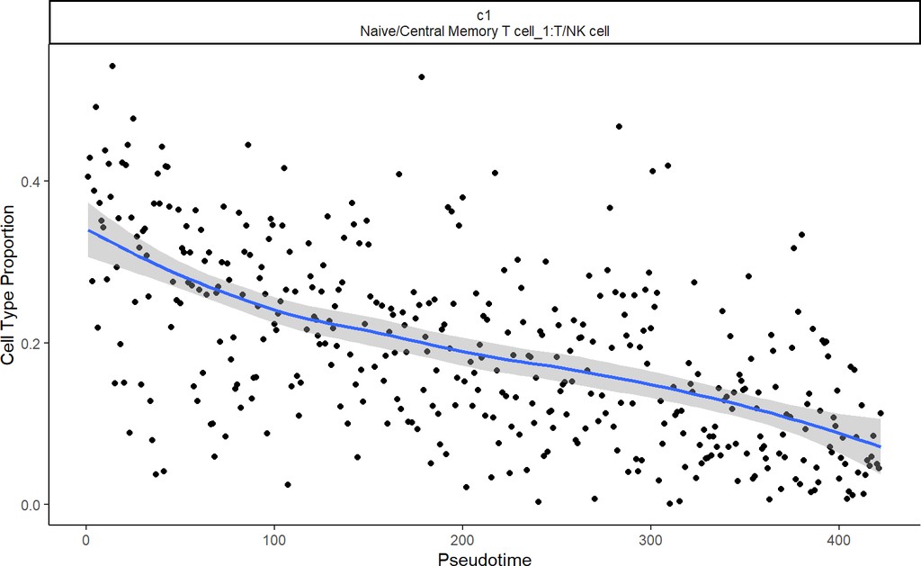

```r
topclu = c(1,2,3,4,8,13,14,24,25); names(topclu) = paste0("c",topclu)
topct = celltype_info$celltype[topclu]

p1 = get_cell_prop_traj(cell_type_prop,cluster_list = topclu[1], celltype_list = topct[1],
                       sample_metadata = sample_info_opt)
p1
```

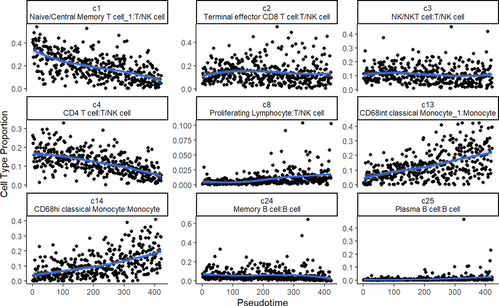

```r
p = get_cell_prop_traj(cell_type_prop,cluster_list = topclu, celltype_list = topct,
                       sample_metadata = sample_info_opt)
p
```

## 5.2 Gene Expression

Now we will demonstrate how to detect differential genes along pseudotime, separately for each cell cluster, using the function `run_pseudo_diff_gene`

- `x`: the pseudobulk gene expression data, each row is a gene:cluster feature and each column is a sample.
- `cluster`: the cell cluster.
- `sample_metadata`: patient-level metadata, including several important variables.
- `sample_name` and `pseudotime_name`: the variable name in `sample_metadata` that indicates the sample and pseudotime. The default setting of `sample_name` is “Patient” and `pseudotime_name` is “Pseudotime”.
- `plot`: logical. Indicate whether to plot the heatmap or not.

```r
run_pseudo_diff_gene = function(x, sample_metadata = NULL, cluster = 1,
                         sample_name = 'Patient', pseudotime_name = 'Pseudotime',
                         plot = F
                         ){
  #print(cluster)
  ptime = sample_metadata[,pseudotime_name]
  sample_metadata = sample_metadata[order(ptime),]

  fn = rownames(x)
  gn = gsub('(.*):(.*)','\\1',fn)
  cn = gsub('(.*):(.*)','\\2',fn)

  xc = x[which(cn == paste0("c",cluster)),]
  xc_reorder = xc[,match(sample_metadata$Patient,colnames(x))]

  res = lapply(1:nrow(xc_reorder), function(i){
    model = mgcv::gam(xc_reorder[i,]~s(c(1:ncol(xc_reorder)),k=3))
    smooth = model$fitted.values
    pval = pchisq(model$null.deviance - model$deviance, model$df.null - model$df.residual,lower.tail = F)
    list(smooth = smooth, pval = pval)
  })
  pval = sapply(res, function(i) i$pval)
  xsmooth = lapply(res, function(i) i$smooth) %>% do.call(rbind, .)
  rownames(xsmooth) = rownames(xc_reorder)


  fdr = p.adjust(pval, method = 'fdr')
  result = data.frame(gene = gsub('(.*):(.*)','\\1',rownames(xc_reorder)), pval = pval, fdr = fdr) %>%
    mutate(cluster = cluster,
           signif = (fdr < 0.05)) %>%
    arrange(fdr)
  print(result)
  sig = result %>% filter(signif) %>% pull(gene)
  sig = paste0(sig,':c',cluster)

  xsig = xsmooth[rownames(xsmooth) %in% sig,]
  xsig = t(apply(xsig, 1, scale))
  rownames(xsig) = gsub('(.*):(.*)','\\1',rownames(xsig))
  colnames(xsig) = colnames(xsmooth)

  if (plot){
    Study.color = readRDS("./data/study.rds")
    Phenotype.color = readRDS("./data/severity.rds")
    patient_annot = HeatmapAnnotation(Severity = sample_metadata$Phenotype,
                                      Study = sample_metadata$Study,
                                      #Sex = sample_info$Sex,
                                      #Age = sample_info$Age,
                                      col = list(Severity = Phenotype.color,
                                                 Study = Study.color),
                                      #Sex = sex.color,
                                      #Age = col_fun),
                                      show_legend = F, simple_anno_size = unit(10,"mm"),
                                      annotation_name_gp = gpar(fontsize = 25)
    )
    p = Heatmap(xsig, name = "Expression",
                show_row_dend = F, cluster_rows = T,
                column_title = "Pseudotime -->", column_title_side = "bottom",
                top_annotation = patient_annot,
                cluster_columns = F, column_dend_reorder=F,
                row_names_gp = gpar(fontsize = 10), row_names_centered = T,
                column_names_gp = gpar(fontsize = 10),
                column_title_gp = gpar(fontsize = 40),
                show_heatmap_legend = F,
                show_column_names = F,
                heatmap_legend_param = list(
                  title_gp = gpar(fontsize = 25),
                  labels_gp = gpar(fontsize = 25),
                  legend_height = unit(8, "cm"),
                  grid_width = unit(1,"cm")
                ))
    print(p)
  }
  return(result)
}
```

```
##       gene         pval          fdr cluster signif
## 1    KLRB1 1.816103e-06 1.089662e-05       1   TRUE
## 2    RPS27 2.587692e-05 7.763076e-05       1   TRUE
## 3 RAP1GAP2 8.851127e-04 1.770225e-03       1   TRUE
## 4   EEF1A1 2.022216e-03 3.033323e-03       1   TRUE
## 5     GZMA 4.958884e-03 5.820275e-03       1   TRUE
## 6    FXYD7 5.820275e-03 5.820275e-03       1   TRUE
```

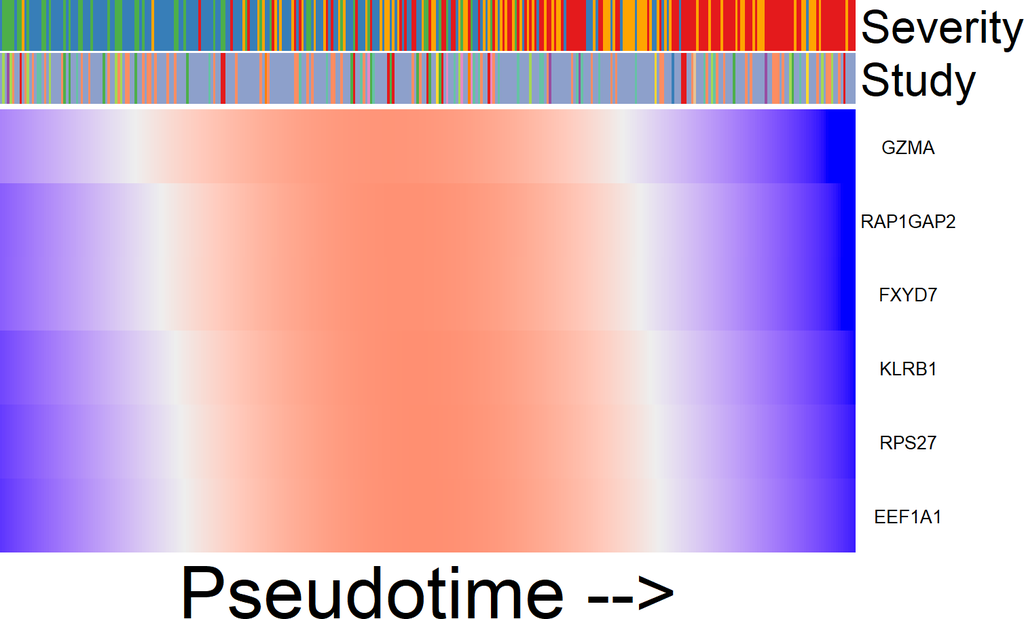

```r
pb_example = readRDS("./data/pb_example_c1.rds")
common_pt = intersect(colnames(pb_example), sample_info_opt$Patient)
sample_info = sample_info_opt %>%
  filter(Patient %in% common_pt)

DEG_result = run_pseudo_diff_gene(x = pb_example, sample_metadata = sample_info, cluster = 1,
                           plot = T)
```

```r
print(DEG_result)
```

```
##       gene         pval          fdr cluster signif
## 1    KLRB1 1.816103e-06 1.089662e-05       1   TRUE
## 2    RPS27 2.587692e-05 7.763076e-05       1   TRUE
## 3 RAP1GAP2 8.851127e-04 1.770225e-03       1   TRUE
## 4   EEF1A1 2.022216e-03 3.033323e-03       1   TRUE
## 5     GZMA 4.958884e-03 5.820275e-03       1   TRUE
## 6    FXYD7 5.820275e-03 5.820275e-03       1   TRUE
```

We can also use the function `get_gene_expr_traj` to explore how the gene expression levels in certain clusters change over pseudotime.

- `x`: the pseudobulk gene expression data, each row is a gene:cluster feature and each column is a sample.
- `gene_list`: the gene list to visualize.
- `cluster`: the cell cluster.
- `sample_metadata`: patient-level metadata, including several important variables.
- ``pseudotime_name`: the variable name in `sample_metadata` that indicates the pseudotime. The default setting of `pseudotime_name` is “Pseudotime”.

```r
get_gene_expr_traj = function(x, gene_list, cluster, sample_metadata,
                              pseudotime_name = 'Pseudotime'){
  ptime = sample_metadata[,pseudotime_name]
  sample_metadata = sample_metadata[order(ptime),]
  xg = x[paste0(gene_list,":c",cluster),,drop = F]
  colnames(xg) = 1:ncol(xg)
  df = xg %>%
    as.data.frame() %>%
    mutate(gene=rownames(.)) %>%
    pivot_longer(!gene, names_to = 'Pseudotime', values_to = 'Expression') %>%
    mutate(Pseudotime = as.numeric(Pseudotime))
  str(df)
  p = df%>%
    ggplot(aes(x = Pseudotime, y = Expression))+
    geom_point()+ geom_smooth()+
    facet_wrap(vars(gene), scales = "free_y") + theme_classic()
  return(p)
}
p = get_gene_expr_traj(x = pb_example,
                       gene_list = c('GZMA','RAP1GAP2','FXYD7','KLRB1','RPS27','EEF1A1'),
                       cluster = 1,
                       sample_metadata = sample_info)
```

```
## tibble [2,094 x 3] (S3: tbl_df/tbl/data.frame)
##  $ gene      : chr [1:2094] "GZMA:c1" "GZMA:c1" "GZMA:c1" "GZMA:c1" ...
##  $ Pseudotime: num [1:2094] 1 2 3 4 5 6 7 8 9 10 ...
##  $ Expression: num [1:2094] 4.65 4.85 3.54 3.56 2.38 ...
```

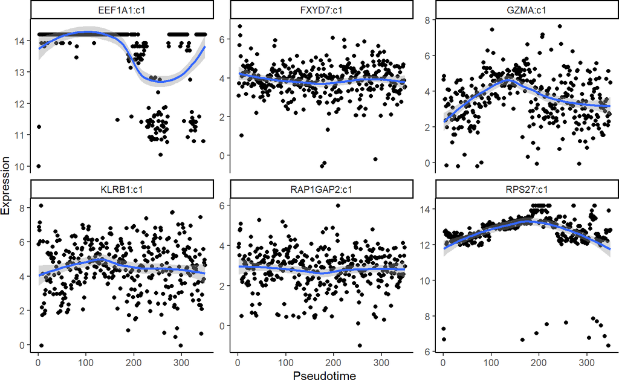

```r
p
```